# **Analysis of the Relationship between Human Genes and Different Leukemia Types**

## Spring 2024 Data Science Project

Contributors: Akshat Parikh, Aadhav Saravanakumar, Samarth Shah

## **Project Contribution Percentage**

Member 1: Akshat Parikh, Contribution: 100% (Contributed equally for all tasks)

Member 2: Aadhav Saravanakumar, Contribution: 100% (Contributed equally for all tasks)

Member 3: Samarth Shah, Contribution: 100% (Contributed equally for all tasks)

We, all team members, agree together that the above information is true, and we are confident about our contributions to this submitted project/final tutorial - Akshat Parikh (05/06/2024), Aadhav Saravakumar (05/06/2024), and Samarth Shah (05/06/2024)

## **Summary of Member Contributions**

Akshat: We all brainstormed for this project together and curated the dataset together from Kaggle (Checkpoints A and B). For data preprocessing and summary statistics, our group held a group coding session where we all interacted with the dataset (Checkpoint B). For data exploration, Akshat wrote the code and explained it for our exploratory method to find outliers in the types of leukemia (Checkpoint C). For designing and training the machine learning models, Akshat wrote the code and trained our dataset for the Multilayer Perceptron neural network and the Decision Tree classifier (Checkpoint D). Akshat also wrote the descriptions for these models that explain how we structured the code and our results on the testing data (Checkpoint E). Finally, we had another group coding session where we created visualizations for our analysis and wrote the conclusion and analysis for our results (Checkpoint F). In this meeting, we also created our final project tutorial by formatting all of our descriptions and code (Checkpoint G). Overall, Akshat contributed to every aspect of the project and put in an equal amount of effort compared to the rest of the group.

Samarth: We all came up with the project idea and curated our dataset for the project (Checkpoints A and B). We also had a group meeting where we performed some preliminary data preprocessing and calculated summary statistics. Samarth wrote the code and description for one of our data exploratory methods that used a two-sample T-test to determine the difference in gene expression levels between different genes (Checkpoint C). Samarth designed and trained the Support Vector Machine classifiers for the machine learning aspect of the project. Samarth also wrote a description for this classifier to explain its function and its accuracy on our testing data (Checkpoints D and E). Finally, we all worked joinly on the visualizations for our dataset and the description of the insights of our results (Checkpoint F). We created and formatted the entire final project tutorial together as well (Checkpoint G).

Aadhav: Aadhav helped come up with the project idea (Checkpoint A). He helped with finding the data and helped preprocess the data for its use (Checkpoint B). He helped with the project by sitting down with the group and deriving conclusions from the summary statistics (Checkpoint C). He was responsible for the ANOVA test, which was done on the gene expression levels (Checkpoint D). He was responsible for the training and data analysis of the Random Forest method used in the project (Checkpoint E). He worked together with the group and helped contribute to the conclusion and visualization by writing some code (Checkpoint F). He also helped put together the final report with the rest of the group (Checkpoint G).

## **Introduction**

Leukemia is a cancer of the blood cells, frequently starting with the overproduction of white blood cells which can impair the ability of a person’s body to produce platelets and red blood cells. Less red blood cells and platelets weaken a person’s immune system, making them more susceptible to other diseases and illnesses. Leukemia can also develop unconsciously, with signs sometimes emerging only after leukemic cells have infiltrated various organs. With these factors under consideration, leukemia is a crucial research area in medicine to improve the well-being of millions around the world.

To this end, we decided to find a dataset involving leukemia such that we could use machine learning and data science to answer some important questions in this area. In our project, we mainly focus on 5 different types of leukemia: Acute Leukemia CD34, Bone Marrow Leukemia, Acute Myeloid Leukemia, Peripheral Blood Leukemia, and Peripheral Blood Stem Cell Leukemia. The different types of leukemia are classified based on the type of blood cell it affects. Bone Marrow Leukemia affects blood cells in the bone marrow, Acute Leukemia CD34 affects white blood cells, and Peripheral Blood Stem Cell Leukemia affects stem cells from the circulating blood. The dataset from our project provides information on which type of leukemia a patient is affected by and their gene expression levels for over 1000 different human genes. Our goal with this project is to somehow use these gene expression levels and discover a pattern in the data that we can use to predict the type of leukemia diagnosis a patient has. This brings us to the main research question of our project which is: how do human gene expression levels affect the type of leukemia diagnosis a patient has?

Analyzing this problem can help doctors diagnose a specific type of leukemia and help the patient receive the best possible treatment. There are many options for treatment such as chemotherapy, targeted therapy, radiation therapy, immunotherapy, and bone marrow transplant which all differ based on the type of leukemia. To make the best decision, a doctor could measure the gene expression levels of a particular patient and use the model we created in this project to accurately identify the type of leukemia in their patients. As mentioned before, traditional leukemia diagnostic tests can only determine the presence of leukemia after certain symptoms exhibit themselves, usually after a substantial amount of time. Thus, by using gene expression levels to predict the type of leukemia, we will be able to perform a leukemia diagnostic test much earlier than the other tests, helping doctors catch the disease in patients quickly. Overall, leukemia’s rise in prevalence along with its 5-year survival rate of 65.7% makes it a crucial sector of medicine that we will investigate in this project, and by answering our research question, we will be able to diagnose patients quicker and more accurately.

## **Data Curation**

To find an appropriate dataset for our problem, we searched through Kaggle for datasets involving leukemia, where we found the [Leukemia Gene Expression dataset](https://www.kaggle.com/datasets/brunogrisci/leukemia-gene-expression-cumida/data) from the CuMiDa database. [CuMiDa](https://sbcb.inf.ufrgs.br/cumida) stands for Curated Microarray Database, which is a collection of 78 cancer datasets that was curated from over 30,000 studies by the Structural Bioinformatics and Computational Biology Lab from the Federal University of Rio Grande do Sul. The dataset on Kaggle is a subset taken from this database that just focuses on leukemia-based cancers. The academic citation for this dataset can be found in the references section.

In this dataset, every row represents a different leukemia patient, and there are 64 total samples in the dataset. In the dataset, there is a column for the type of cancer. There are five different types of leukemia in the dataset: Acute Leukemia CD34, Bone Marrow Leukemia, Acute Myeloid Leukemia, Peripheral Blood Leukemia, and Peripheral Blood Stem Cell Leukemia. The type of leukemia is the dependent variable in this dataset.

The rest of the columns are the names of 22283 different gene probes, and every row has the gene expression levels for all these probes. These gene expression levels are the features of this dataset. The dataset authors did not go into detail on how the gene expression levels were measured using the probes, but it probably involved a process of taking an RNA sample from each patient and then using some blotting technique to extract information about specific RNA molecules.

The dataset can be downloaded from Kaggle by signing in and using the following link: https://www.kaggle.com/datasets/brunogrisci/leukemia-gene-expression-cumida/download?datasetVersionNumber=1. This will download an “archive.zip” file which you should then unzip. The extracted directory will have a file named “Leukemia_GSE9476.csv” which should be stored in the main project directory.

You can also run the following commands to setup the project directory if you have already downloaded "archive.zip" to your workspace.

```python
!unzip archive.zip -d archive
!mv archive/Leukemia_GSE9476.csv .
```

We will be doing the entirety of our data analysis in this Python Jupyter notebook, so before we start, we need to import some libraries.

```python
#Import packages for data analysis
import pandas as pd
import numpy as np
from scipy import stats
import matplotlib.pyplot as plt
import seaborn as sns
```

## **Data Preprocessing**

We first need to load our dataset into a dataframe. In our dataset, each row represents a different sample which is a patient/person that has been affected by leukemia. The original dataset has one column to represent the type of leukemia that the sample has. The rest of the columns are named after different gene probes and their values represent the gene expression levels for that specific probe.

```python
#Organize dataset into Pandas dataframe
df = pd.read_csv('Leukemia_GSE9476.csv', index_col = 0)
df.head(10)
```

| samples | type | 1007_s_at | 1053_at | 117_at | 121_at | 1255_g_at | 1294_at | 1316_at | 1320_at | 1405_i_at | ... | AFFX-r2-Hs28SrRNA-5_at | AFFX-r2-Hs28SrRNA-M_at | AFFX-r2-P1-cre-3_at | AFFX-r2-P1-cre-5_at | AFFX-ThrX-3_at | AFFX-ThrX-5_at | AFFX-ThrX-M_at | AFFX-TrpnX-3_at | AFFX-TrpnX-5_at | AFFX-TrpnX-M_at |
| --- | --- | --- | --- | --- | --- | --- | --- | --- | --- | --- | --- | --- | --- | --- | --- | --- | --- | --- | --- | --- | --- |
| 1 | Bone_Marrow_CD34 | 7.745245 | 7.811210 | 6.477916 | 8.841506 | 4.546941 | 7.957714 | 5.344999 | 4.673364 | 4.664924 | ... | 5.058849 | 6.810004 | 12.800060 | 12.718612 | 5.391512 | 4.666166 | 3.974759 | 3.656693 | 4.160622 | 4.139249 |
| 12 | Bone_Marrow_CD34 | 8.087252 | 7.240673 | 8.584648 | 8.983571 | 4.548934 | 8.011652 | 5.579647 | 4.828184 | 5.171835 | ... | 4.436153 | 6.751471 | 12.472706 | 12.333593 | 5.379738 | 4.656786 | 4.188348 | 3.792535 | 4.204414 | 4.122700 |
| 13 | Bone_Marrow_CD34 | 7.792056 | 7.549368 | 11.053504 | 8.909703 | 4.549328 | 8.237099 | 5.406489 | 4.615572 | 4.775709 | ... | 4.392061 | 6.086295 | 12.637384 | 12.499038 | 5.316604 | 4.600566 | 3.845561 | 3.635715 | 4.174199 | 4.067152 |
| 14 | Bone_Marrow_CD34 | 7.767265 | 7.094460 | 11.816433 | 8.994654 | 4.697018 | 8.283412 | 5.582195 | 4.903684 | 4.829844 | ... | 4.633334 | 6.375991 | 12.903630 | 12.871454 | 5.179951 | 4.641952 | 3.991634 | 3.704587 | 4.149938 | 3.910150 |
| 15 | Bone_Marrow_CD34 | 8.010117 | 7.405281 | 6.656049 | 9.050682 | 4.514986 | 8.377046 | 5.493713 | 4.860754 | 5.245049 | ... | 5.305192 | 6.700453 | 12.949352 | 12.782515 | 5.341689 | 4.560315 | 3.887020 | 3.629853 | 4.127513 | 4.004316 |
| 16 | Bone_Marrow_CD34 | 7.830279 | 7.025275 | 7.193019 | 9.114221 | 4.584802 | 8.205780 | 5.641085 | 4.765249 | 4.658020 | ... | 4.250235 | 6.155386 | 13.292661 | 13.234471 | 5.250568 | 4.605257 | 3.864205 | 3.735947 | 4.109941 | 4.139532 |
| 17 | Bone_Marrow_CD34 | 8.167701 | 6.949900 | 7.604404 | 9.326422 | 4.754915 | 7.331400 | 5.908871 | 5.193624 | 4.962044 | ... | 4.650690 | 6.836679 | 13.239335 | 13.024450 | 5.635133 | 4.831326 | 4.118359 | 3.676294 | 4.290143 | 4.232628 |
| 18 | Bone_Marrow_CD34 | 7.712012 | 7.962858 | 10.549554 | 9.071372 | 4.516647 | 8.111130 | 5.578826 | 4.757115 | 4.822522 | ... | 4.643991 | 6.412188 | 12.761211 | 12.515943 | 5.284926 | 4.690645 | 3.824535 | 3.552306 | 4.069378 | 4.083583 |
| 2 | Bone_Marrow | 7.966060 | 6.781246 | 6.920990 | 8.978862 | 4.478028 | 7.683032 | 5.610469 | 4.824193 | 7.502364 | ... | 4.742075 | 6.794769 | 13.524380 | 13.400021 | 5.327728 | 4.631000 | 3.897626 | 3.671963 | 4.002604 | 4.058350 |
| 3 | Bone_Marrow | 7.692476 | 6.775148 | 6.616971 | 8.706216 | 4.443770 | 7.692134 | 5.501473 | 4.558013 | 9.985429 | ... | 5.082368 | 6.913332 | 12.511607 | 12.470305 | 5.224274 | 4.517029 | 3.844456 | 3.587143 | 4.119111 | 3.985250 |

10 rows × 22284 columns

As shown above, the original dataset has abbreviations and medical terms for the leukemia types, so we need to do some preprocessing to parse these abbreviations and convert them to actual names. This will make it easier for us to use the actual names in visualizations and conclusions. The new names are represented in a new column named 'actual_type'.

```python
leukemia_types = {
    'Bone_Marrow_CD34': 'Acute Leukemia CD34',
    'Bone_Marrow': 'Bone Marrow Leukemia',
    'AML': 'Acute Myeloid Leukemia',
    'PB': 'Peripheral Blood Leukemia',
    'PBSC_CD34': 'Peripheral Blood Stem Cell Leukemia'
}

#Parse the original Leukemia types and convert them to actual names
df['actual_type'] = df['type'].map(leukemia_types)
```

Furthermore, the final goal for our project is to use the features (gene expression levels) of the dataset to train a machine learning model to predict the type of leukemia that a particular sample has. For many machine learning models and neural networks, it is easier to define the label for a classification task as a numerical value rather than a string for each class. Thus, we need to convert the leukemia types, which will be our labels, into numerical values. This is represented in a new column named 'mapped_type'.

```python
#Parse the original Leukemia types and convert them to integers for easier analysis
df['mapped_type'] = df['type'].astype('category').cat.codes
```

This is all the data preprocessing we had to do for our dataset because the authors already did a signficant amount of preprocessing. As shown below, the dataset does not have missing values as the authors removed them, meaning we do not have to do imputation. They also normalized all the gene expression levels for each probe. The new version of the dataset is also display below.

```python
#Check if there is missing data in dataset
print(f"Missing data in dataset: {df.isnull().values.any()}")

#Drop any rows with missing data
df.dropna()

df.head()
```

```
Missing data in dataset: False
```

| samples | type | 1007_s_at | 1053_at | 117_at | 121_at | 1255_g_at | 1294_at | 1316_at | 1320_at | 1405_i_at | ... | AFFX-r2-P1-cre-3_at | AFFX-r2-P1-cre-5_at | AFFX-ThrX-3_at | AFFX-ThrX-5_at | AFFX-ThrX-M_at | AFFX-TrpnX-3_at | AFFX-TrpnX-5_at | AFFX-TrpnX-M_at | actual_type | mapped_type |
| --- | --- | --- | --- | --- | --- | --- | --- | --- | --- | --- | --- | --- | --- | --- | --- | --- | --- | --- | --- | --- | --- |
| 1 | Bone_Marrow_CD34 | 7.745245 | 7.811210 | 6.477916 | 8.841506 | 4.546941 | 7.957714 | 5.344999 | 4.673364 | 4.664924 | ... | 12.800060 | 12.718612 | 5.391512 | 4.666166 | 3.974759 | 3.656693 | 4.160622 | 4.139249 | Acute Leukemia CD34 | 2 |
| 12 | Bone_Marrow_CD34 | 8.087252 | 7.240673 | 8.584648 | 8.983571 | 4.548934 | 8.011652 | 5.579647 | 4.828184 | 5.171835 | ... | 12.472706 | 12.333593 | 5.379738 | 4.656786 | 4.188348 | 3.792535 | 4.204414 | 4.122700 | Acute Leukemia CD34 | 2 |
| 13 | Bone_Marrow_CD34 | 7.792056 | 7.549368 | 11.053504 | 8.909703 | 4.549328 | 8.237099 | 5.406489 | 4.615572 | 4.775709 | ... | 12.637384 | 12.499038 | 5.316604 | 4.600566 | 3.845561 | 3.635715 | 4.174199 | 4.067152 | Acute Leukemia CD34 | 2 |
| 14 | Bone_Marrow_CD34 | 7.767265 | 7.094460 | 11.816433 | 8.994654 | 4.697018 | 8.283412 | 5.582195 | 4.903684 | 4.829844 | ... | 12.903630 | 12.871454 | 5.179951 | 4.641952 | 3.991634 | 3.704587 | 4.149938 | 3.910150 | Acute Leukemia CD34 | 2 |
| 15 | Bone_Marrow_CD34 | 8.010117 | 7.405281 | 6.656049 | 9.050682 | 4.514986 | 8.377046 | 5.493713 | 4.860754 | 5.245049 | ... | 12.949352 | 12.782515 | 5.341689 | 4.560315 | 3.887020 | 3.629853 | 4.127513 | 4.004316 | Acute Leukemia CD34 | 2 |

5 rows × 22286 columns

## **Summary Statistics**

Before we explore the data, we need to understand how the dataset is structured and what the current distribution of data looks like. Thus, we need to calculate some summary statistics about the main variables at focus (gene expression levels, type of leukemia) to gain this information. The Python code below calculates the summary statistics for these variables on our dataset.

```python
#Basic Data Exploration
print(f'Number of samples in dataset: {len(df)}')
print(f'Number of gene probes (features) in dataset: {len(df.columns) - 3}')
print(f"Types of Leukemia Detected in Samples:\n{', '.join(df['actual_type'].unique())}\n")

#Organize the number of samples based on Leukemia type
type_counts = df['actual_type'].value_counts()

print("Number of Samples for Each Type:")
print(type_counts)
print("\n")

#Summary Statistics
print("Summary Statistics of Number of Samples for Leukemia Types:")
print(type_counts.describe())

print(f"\nMode of Number of Samples for Leukemia Types: Acute Myeloid Leukemia (26)")
print(f"Min of Number of Samples for Leukemia Types: Acute Leukemia CD34 (8)")
print(f"Mean of Number of Samples for Leukemia Types: {12.8}")
print(f"Standard Deviation of Number of Samples for Leukemia Types: {7.42}")
```

```
Number of samples in dataset: 64
Number of gene probes (features) in dataset: 22283
Types of Leukemia Detected in Samples:
Acute Leukemia CD34, Bone Marrow Leukemia, Acute Myeloid Leukemia, Peripheral Blood Leukemia, Peripheral Blood Stem Cell Leukemia

Number of Samples for Each Type:
Acute Myeloid Leukemia                 26
Bone Marrow Leukemia                   10
Peripheral Blood Leukemia              10
Peripheral Blood Stem Cell Leukemia    10
Acute Leukemia CD34                     8
Name: actual_type, dtype: int64


Summary Statistics of Number of Samples for Leukemia Types:
count     5.00000
mean     12.80000
std       7.42967
min       8.00000
25%      10.00000
50%      10.00000
75%      10.00000
max      26.00000
Name: actual_type, dtype: float64

Mode of Number of Samples for Leukemia Types: Acute Myeloid Leukemia (26)
Min of Number of Samples for Leukemia Types: Acute Leukemia CD34 (8)
Mean of Number of Samples for Leukemia Types: 12.8
Standard Deviation of Number of Samples for Leukemia Types: 7.42
```

From the summary statistics, we can see that the average number of samples is 12.8 with the standard deviation being 7.42. This shows that there is a substantial variability among the types of leukemia. This is confirmed by the sample counts, where most leuekemia types have 10 samples with the exceptions being Acute Myleoid Leukemia with 26 samples, and Acute Leukemia CD34 with 8. This indicates that some types of leukemia are better represented by the dataset than others, which can affect the models' ability to accurately diagnosis different types of leukemia. The summary statistics also showed that we have 22283 gene probes which is substantial amount of features to have in our dataset.

## **Exploratory Data Analysis**

### **Statistical Method 1 (Z-Test for Outliers)**

From our basic data exploration and summary statistics, we can see that the number of samples for Acute Myeloid Leukemia is significantly larger than the population mean number of samples for leukemia types which is 12.8. Thus, we can use a Z-Test to determine whether the number of samples for Acute Myeloid Leukemia is an outlier in the dataset.

Z-Test Hypotheses

H0: The number of samples for Acute Myeloid Leukemia is not an outlier.

HA: The number of samples for Acute Myeloid Leukemia is an outlier.

Our significance level for this test will be 0.05.

Run the following Python code to perform the Z-Test on our dataset by first calculating the Z-Score for the number of samples for the AML type and then comparing whether the Z-Score is greater than some critical value.

```python
#Statistical Method 1: Z-Test to Determine Outliers
z_score = ((len(df[df['type'] == 'AML']) - type_counts.mean()) / np.std(type_counts))
print(f"Z-Score: {z_score}")
critical_value = stats.norm.ppf(1-0.05/2)
if z_score >  critical_value:
    print("Reject Null Hypothesis")
else:
  print("Fail to Reject Null Hypothesis")
```

```
Z-Score: 1.9863665759151916
Reject Null Hypothesis
```

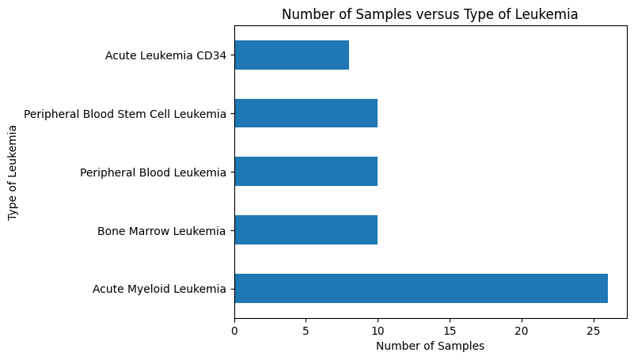

```python
#Bar chart to show distribution of Leukemia types and possible outliers
figure = type_counts.plot(kind='barh')
figure.set_title("Number of Samples versus Type of Leukemia")
figure.set_xlabel("Number of Samples")
figure.set_ylabel("Type of Leukemia")
plt.show()
```

Using the Z-Test, we can determine that there was statistically signficant evidence to reject the null hypothesis and conclude that the number of samples for Acute Myeloid Leukemia is indeed an outlier in this dataset. Our conclusion is also further supported in the figure displayed above, where it shows that all the other leukemia types have about 10 samples, but the Acute Myeloid Leukemia type has more than double the number of samples. Finally, our conclusion is supported by current medical research, where the Mayo Clinic reported that by far the most common type of leukemia is Acute Myeloid Leukemia (https://www.mayoclinic.org/diseases-conditions/leukemia/symptoms-causes/syc-20374373).

### **Statistical Method 2 (ANOVA Test)**

From our summary statistics, we can see that there are over 22283 gene probes (features) in our dataset, and we aim to use the gene expression levels from these features to train a machine-learning model that can classify different types of leukemia. We would like to determine if there are major differences in these gene expression levels between all the different types of leukemia as that might provide information on what features are associated with each type of leukemia. Thus, we can perform an ANOVA test among the different types of leukemia and the gene expression levels to determine if there is a statistical difference between the different types.

Our code below can be changed to work with any gene in the dataset. For this ANOVA test, we will be focusing primarily on the RUNX1 gene as the American Cancer Society reported that it was the most common gene among patients (https://www.cancer.org/cancer/types/acute-myeloid-leukemia/causes-risks-prevention/what-causes.html).

ANOVA Test Hypotheses

H0: There is no significant correlation between the type of Leukemia and the gene expression levels for the RUNX1 gene.

HA: There is a significant correlation between the type of Leukemia and the gene expression levels for the RUNX1 gene.

Our significance level for this test will be 0.05.

Run the following Python code to perform an ANOVA test by first getting the gene expression levels for the desired gene for each type of leukemia. Then, the code just performs an ANOVA test and checks whether the P-Value is below our significance level.

```python
#Statistical Method 2: ANOVA Test
gene_name = "210365_at" #Converted RUNX1 to probe name

#Extract gene expression levels for each type of leukemia
bone_marrow_cd34_col = df[df['type'] == "Bone_Marrow_CD34"][gene_name]
pbsc_cd34_col = df[df['type'] == "PBSC_CD34"][gene_name]
bone_marrow_col = df[df['type'] == "Bone_Marrow"][gene_name]
pb_col = df[df['type'] == "PB"][gene_name]
aml_col = df[df['type'] == "AML"][gene_name]

#Calculate P-Value using an ANOVA test
f_statistic, p_value = stats.f_oneway(bone_marrow_cd34_col, pbsc_cd34_col, bone_marrow_col, pb_col, aml_col)

print(f"P-Value: {p_value}")

if p_value < 0.05:
    print("Reject Null Hypothesis")
else:
  print("Fail to Reject Null Hypothesis")
```

```
P-Value: 1.6674886159238112e-12
Reject Null Hypothesis
```

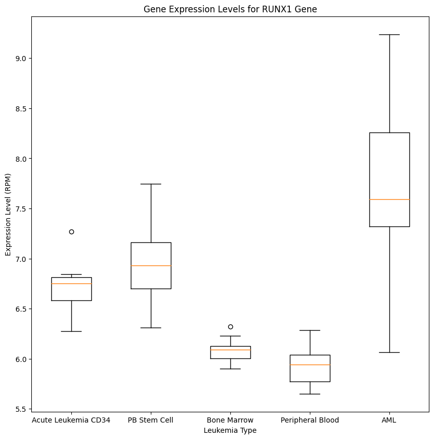

```python
# Box and whisker plot of all the different gene expression levels for RUNX1
plt.figure(figsize=(10, 10))

plt.boxplot([bone_marrow_cd34_col, pbsc_cd34_col, bone_marrow_col, pb_col, aml_col],
             labels=['Acute Leukemia CD34', 'PB Stem Cell',
                     'Bone Marrow', 'Peripheral Blood', 'AML'])

plt.title(f'Gene Expression Levels for RUNX1 Gene')
plt.xlabel('Leukemia Type')
plt.ylabel('Expression Level (RPM)')
plt.show()
```

Using the ANOVA test, we can determine that there was statistically signficant evidence to reject the null hypothesis and conclude that there is a correlation between the type of leukemia a person has and the gene expression level of the RUNX1 gene. This is further supported in our box and whisker plot, where we can see that each type of leukemia has a different median gene expression level (orange line on plot). This analysis shows us that the gene expression levels do vary across the types of leukemia, meaning that these features do have some pattern distinct to each type that can be determined using machine-learning models.

### **Statistical Method 3: Two Sample T-Test**

Another relationship we can investigate is if any genes themselves have correlated gene expression levels. This is important for us because we can use this info to select more features from our dataset to include when training our final model.

For this T-Test, we will be focusing primarily on if there is a difference between the gene expression levels of the RARA and DDR1 genes as the American Cancer Society reported that these genes were common among leukemia patients (https://www.cancer.org/cancer/types/acute-myeloid-leukemia/causes-risks-prevention/what-causes.html). Our code can be modified to use the T-Test for any two genes in our dataset.

Two-Sample T-Test Hypotheses

H0: There is a significant difference among the gene expression levels between the RARA and DDR1 genes.

HA: There isn't a significant difference among the gene expression levels between the RARA and DDR1 genes.

Our significance level for this test will be 0.05.

Run the following Python code to extract the gene expression levels for these two genes and then perform a T-Test on the data. The code then uses the resulting P-Value and compares it to our significance level.

```python
#Statistical Method 3: Two Sample T-Test
stat, p_value = stats.ttest_ind(df['209458_x_at'], df['211745_x_at']) #Convert the gene names to probe names
print(f"P-Value: {p_value}")

if p_value < 0.05:
    print("Reject Null Hypothesis")
else:
  print("Fail to Reject Null Hypothesis")
```

```
P-Value: 0.9773976463657493
Fail to Reject Null Hypothesis
```

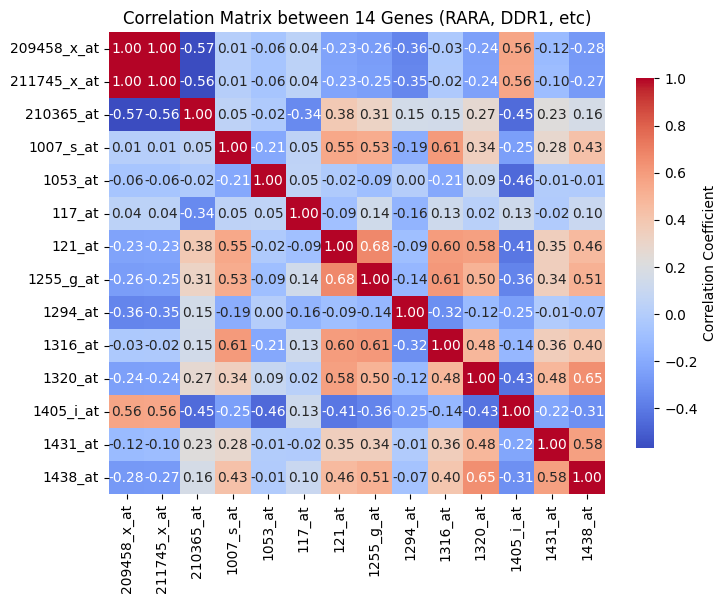

```python
#Correlation Matrix between RARA and DDR1 and some other genes
cols = ["209458_x_at", "211745_x_at", "210365_at", '1007_s_at', '1053_at', '117_at', '121_at', '1255_g_at',
       '1294_at', '1316_at', '1320_at', '1405_i_at', '1431_at', '1438_at']

#Calculate correlation matrix
corr_matrix = df[cols].corr()

#Print heatmap of correlation matrix
plt.figure(figsize=(8, 6))
sns.heatmap(corr_matrix, annot=True, cmap='coolwarm', cbar=True, fmt=".2f",
            cbar_kws={'shrink': 0.8, 'label': 'Correlation Coefficient'})
plt.title(f"Correlation Matrix between 14 Genes (RARA, DDR1, etc)")
plt.show()
```

Using the two-sample T-Test, we can determine that there isn't statistically signficant evidence to reject the null hypothesis as the p-value was larger than the significance level. This means we can conclude that there is some correlation or difference between the gene expression levels of the RARA and DDR1 genes.

## **Primary Analysis**

From our prior data analysis, we were able to determine some of the key aspects of this dataset. Firstly, our analysis showed that the dataset has a categorical 'type' column that represents the type of leukemia for a sample. The rest of the columns represent the gene expression levels for different gene probes collected on each patient in the dataset. To answer our research question, we would like to train a machine learning model that can use these gene expression levels (features) to correctly predict the type of leukemia (dependent variable) a patient has.

Since the dependent variable is categorical and we have labels in our dataset (type of leukemia), we will be using classification as primary analysis techinique because it is a supervised machine learning techinique that works well on labeled datasets and discrete output data.

In addition, our prior analysis revealed other important information that we must incorporate into our primary analysis. Our first finding from the Z-Test showed that among the different types of leukemia, the AML type is an outlier for the number of samples. This finding will impact our primary analysis as we will need to account for this outlier when training our models. Another finding from the T-Test showed that the gene expression levels between the RARA and DDR1 genes have some correlation. This finding impacts our primary analysis because in many cases, correlated variables will boost a model's performance, so we can either use the correlation matrix or the T-Test code to extract correlated variables and use them as features for our model.

For our primary analysis, we will be training several different classifier models to determine which type of machine-learning model is best suited for our data and can most accurately predict the type of leukemia a patient has.

**Random Forest/Decision Tree Classifiers**

The first classifier models we will investigate are Random Forest/Decision Tree classifiers. A Decision Tree classifier uses the examples from the training data to create a decision tree that maps the possible classes through a series of choices of the features. Random Forest is just an ensemble method that uses multiple decision trees to come to a singular result.

The following code trains these classifiers on our training data and evaluates their performance on the testing data.

```python
#Import packages needed for primary analysis
from sklearn.preprocessing import StandardScaler
from sklearn.ensemble import RandomForestClassifier
from sklearn.model_selection import train_test_split
from sklearn.metrics import confusion_matrix
from sklearn.metrics import accuracy_score
from sklearn.metrics import f1_score
from sklearn.metrics import r2_score
from sklearn import svm
from sklearn.tree import DecisionTreeClassifier
from sklearn.neighbors import KNeighborsClassifier
from sklearn.multiclass import OneVsRestClassifier
from sklearn.neighbors import KNeighborsClassifier
from sklearn.neural_network import MLPClassifier
```

The following Python code extracts the features and output data from our dataset, and then the code splits the features and output into testing and training portions.

```python
#Set up random state for the ML models
random_state = 42

#X is the gene expression levels from our dataset which is every column except the first and last two
X = df.iloc[:, 1:-2]

#Y is the target label which in our dataset is the type of leukemia
y = df['mapped_type']

#Split the dataset into testing and training portions
X_train, X_test, y_train, y_test = train_test_split(X, y, test_size=0.2, random_state=random_state)
```

We use this code to scale the gene expression levels for each gene probe (feature) in the dataset.

```python
#Use standard scaler to scale all the features
scaler = StandardScaler()
X_train = scaler.fit_transform(X_train)
X_test = scaler.transform(X_test)
```

The following code creates the Random Forest/Decision Tree classifiers and trains the models on our training data. For Random Forest, we have set n_estimators to 2 as during our testing, we performed an iterative search over this hyperparameter and determined this to be the best value.

```python
#Create and fit Random Forest classifier on training data
rf_classifier = RandomForestClassifier(n_estimators = 2, criterion = 'entropy', random_state = random_state)
rf_classifier.fit(X_train, y_train)

#Create and fit DecisionTree classifier on training data
dt_classifier = DecisionTreeClassifier()
dt_classifier.fit(X_train, y_train)
```

```
DecisionTreeClassifier()
```

We use this code to get predictions for the Random Forest model and calculate the f1-score, accuracy, and r^2 score. These will be the main metrics we will use to evaluate the performance of all our machine-learning models on the testing data.

```python
#Get the label predictions (type of leukemia) for all samples in testing dataset
rf_pred = rf_classifier.predict(X_test)

#Calculate the accuracy, f1-score, and r^2 of the Random Forest model on the testing dataset
rf_accuracy = accuracy_score(y_test, rf_pred)
rf_f1 = f1_score(y_test, rf_pred, average='weighted')
rf_r2 = r2_score(y_test, rf_pred)

print(f"Accuracy (Random Forest): {rf_accuracy}")
print(f"F1-Score (Random Forest): {rf_f1}")
print(f"Coefficient of Determination (Random Forest): {rf_r2}")
```

```
Accuracy (Random Forest): 0.8461538461538461
F1-Score (Random Forest): 0.844871794871795
Coefficient of Determination (Random Forest): 0.6542553191489362
```

We use this code to get predictions for the Decision Tree model and calculate the f1-score, accuracy, and r^2 score.

```python
#Get the label predictions (type of leukemia) for all samples in testing dataset
dt_pred = dt_classifier.predict(X_test)

#Calculate the accuracy, f1-score, and r^2 of the Decision Tree model on the testing dataset
dt_accuracy = accuracy_score(y_test, dt_pred)
dt_f1 = f1_score(y_test, dt_pred, average='weighted')
dt_r2 = r2_score(y_test, dt_pred)

print(f"Accuracy (Decision Tree): {dt_accuracy}")
print(f"F1-Score (Decision Tree): {dt_f1}")
print(f"Coefficient of Determination (Decision Tree): {dt_r2}")
```

```
Accuracy (Decision Tree): 0.6153846153846154
F1-Score (Decision Tree): 0.6032967032967034
Coefficient of Determination (Decision Tree): -0.31382978723404276
```

**Support Vector Machine Classifier**

The next classifier model we will use is the Support Vector Machine classifier. The Support Vector Machine classifier works by finding a hyperplane that has the maximal distance between two classes. The Support Vector Machine classifier can only be trained on binary classification tasks, so we need to use the OneVsRestClassifier on top of SVM to turn our multi-class classification task into a binary classification task. This is done by creating separate binary classifiers for each one of the classes in the dataset. We also had to use the SVM kernel trick which allows us to use higher-dimensional input with Support Vector Machines. The kernels we chose to test are rbf and polynomial. For the SVM model with the RBF kernel, I have set the gamma to 0.5 and C to 1 as during testing, we performed an iterative search over these hyperparameters and found these to be the best values. For the SVM model with the poly kernel, I have set the degree to 2 and C to 1 as during testing, we performed an iterative search over these hyperparameters and found these to be the best values.

Run the following code to create the two SVM classifiers, train them on our training data, and evaluate their performance on the testing data.

```python
#Create OneVsRestClassifier instance to do multi-class classification with SVM and rbf kernel
rbf = OneVsRestClassifier(svm.SVC(kernel='rbf', gamma=0.5, C=1))
#Fit the model on the training data
rbf.fit(X_train, y_train)

#Create OneVsRestClassifier instance to do multi-class classification with SVM and poly kernel
poly = OneVsRestClassifier(svm.SVC(kernel='poly', degree=2, C=1))
#Fit the model on the training data
poly.fit(X_train, y_train)
```

```
OneVsRestClassifier(estimator=SVC(C=1, degree=2, kernel='poly'))
```

```python
#Get predictions from the SVM poly and rbf models on the testing data
poly_pred = poly.predict(X_test)
rbf_pred = rbf.predict(X_test)
```

```python
#Calculate the accuracy, f1-score, and r^2 of the SVM (Polynomial Kernel) model on the testing dataset
poly_accuracy = accuracy_score(y_test, poly_pred)
poly_f1 = f1_score(y_test, poly_pred, average='weighted')
poly_r2 = r2_score(y_test, poly_pred)

print(f'Accuracy (SVM Polynomial Kernel): {poly_accuracy}')
print(f'F1-Score (SVM Polynomial Kernel): {poly_f1}')
print(f"Coefficient of Determination (SVM Polynomial Kernel): {dt_r2}")

print("\n")

#Calculate the accuracy, f1-score, and r^2 of the SVM (RBF Kernel) model on the testing dataset
rbf_accuracy = accuracy_score(y_test, rbf_pred)
rbf_f1 = f1_score(y_test, rbf_pred, average='weighted')
rbf_r2 = r2_score(y_test, rbf_pred)

print(f'Accuracy (SVM RBF Kernel): {rbf_accuracy}')
print(f'F1-Score (SVM RBF Kernel): {rbf_f1}')
print(f"Coefficient of Determination (SVM RBF Kernel): {rf_r2}")
```

```
Accuracy (SVM Polynomial Kernel): 0.7692307692307693
F1-Score (SVM Polynomial Kernel): 0.7794871794871795
Coefficient of Determination (SVM Polynomial Kernel): -0.31382978723404276


Accuracy (SVM RBF Kernel): 0.23076923076923078
F1-Score (SVM RBF Kernel): 0.08653846153846154
Coefficient of Determination (SVM RBF Kernel): 0.6542553191489362
```

**K-Nearest Neighbor Classifier**

The next classifier model we will investigate in our primary analysis is the K-Nearest Neighbor classifier. The KNN classifier calculates the K nearest data points in the feature space, measured by some distance function, and takes the majority class of these data points. KNN can only be used effectively for binary classification, so to do multi-class classification, we need to use the OneVsRestClassifier on top of KNN. Finally, we have set the value for K to be 18 in this model because during our testing, we performed an iterative search over this hyperparameter and found this to be the best value.

Run the following code to create the KNN classifier, train the model on our dataset, and evaluate its performance on the testing data.

```python
#Create OneVsRestClassifier instance to do multi-class classification with KNN
knn = OneVsRestClassifier(KNeighborsClassifier(18))
#Fit the model on training data
knn.fit(X_train, y_train)

#Get predictions of model on testing data
knn_pred = knn.predict(X_test)

#Calculate the accuracy, f1-score, and r^2 of the KNN model on the testing dataset
knn_accuracy = accuracy_score(y_test, knn_pred)
knn_f1 = f1_score(y_test, knn_pred, average='weighted')
knn_r2 = r2_score(y_test, knn_pred)

print(f"Accuracy (KNN): {knn_accuracy}")
print(f"F1 (KNN): {knn_f1}")
print(f"Coefficient of Determination (KNN): {knn_r2}")
```

```
Accuracy (KNN): 0.6923076923076923
F1 (KNN): 0.6388278388278388
Coefficient of Determination (KNN): 0.031914893617021156
```

**Multilayer Perceptron Classifier**

The final classifier model we will investigate is the Multilayer Perceptron classifier. The Multilayer Perceptron classifier creates a fully-connected deep neural network that can be used for multi-class classification tasks. This model worked very easily with our dataset and did not require any extra hyperparameter tuning.

```python
#Create instance of MLP classifier model
mlp = MLPClassifier()
#Fit model to training data
mlp.fit(X_train, y_train)

#Get predictions of model on testing data
mlp_pred = mlp.predict(X_test)

#Calculate the accuracy, f1-score, and r^2 of the MLP model on the testing dataset
mlp_accuracy = accuracy_score(y_test, mlp_pred)
mlp_f1 = f1_score(y_test, mlp_pred, average='weighted')
mlp_r2 = r2_score(y_test, mlp_pred)

print(f"Accuracy (MLP): {mlp_accuracy}")
print(f"F1 (MLP): {mlp_f1}")
print(f"Coefficient of Determination (MLP): {mlp_r2}")
```

```
Accuracy (MLP): 0.9230769230769231
F1 (MLP): 0.9208791208791209
Coefficient of Determination (MLP): 0.9654255319148937
```

## **Visualization**

To visualize our results from the primary analysis, we will create a confusion matrix for every classifier that we previously trained. The confusion matrix shows how many predictions on the testing data are correct or incorrect for every class. This can help us understand if a model is underperforming for any particular class in our dataset.

Run all the following Python code blocks to visualize the confusion matricies for all classifiers that we previously trained.

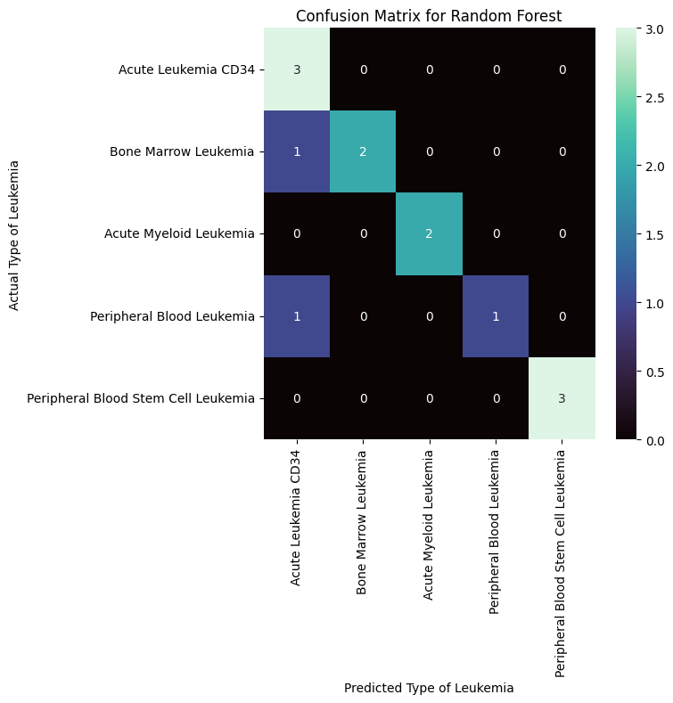

```python
#Calculate the confusion matrix for Random Forest
cm = confusion_matrix(y_test, rf_pred)

#Visualizing the confusion matrix using seaborn
plt.figure(figsize=(6,6))
sns.heatmap(cm, annot=True, cmap='mako', xticklabels=df['actual_type'].unique(), yticklabels=df['actual_type'].unique())
plt.title("Confusion Matrix for Random Forest")
plt.xlabel('Predicted Type of Leukemia')
plt.ylabel('Actual Type of Leukemia')
plt.show()
```

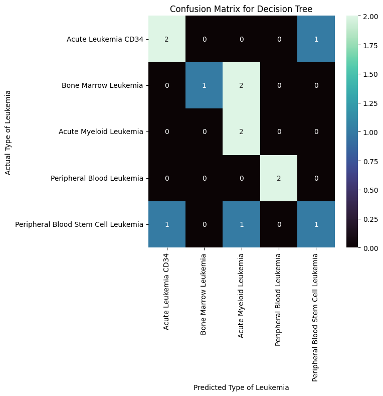

```python
#Calculate the confusion matrix for Decision Tree
cm = confusion_matrix(y_test, dt_pred)

#Visualizing the confusion matrix using seaborn
plt.figure(figsize=(6,6))
sns.heatmap(cm, annot=True, cmap='mako', xticklabels=df['actual_type'].unique(), yticklabels=df['actual_type'].unique())
plt.title("Confusion Matrix for Decision Tree")
plt.xlabel('Predicted Type of Leukemia')
plt.ylabel('Actual Type of Leukemia')
plt.show()
```

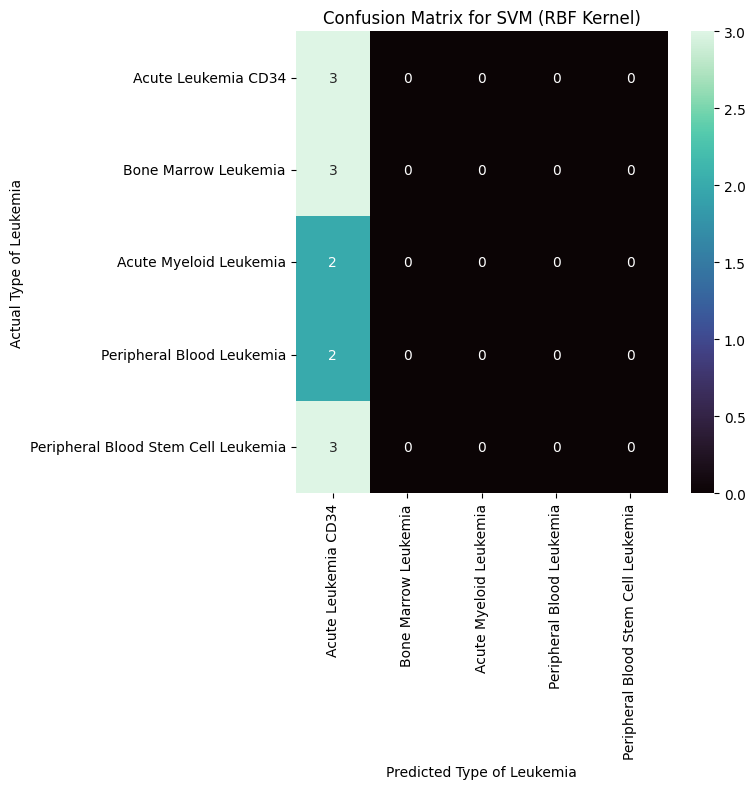

```python
#Calculate the confusion matrix for SVM (RBF Kernel)
cm = confusion_matrix(y_test, rbf_pred)

#Visualizing the confusion matrix using seaborn
plt.figure(figsize=(6,6))
sns.heatmap(cm, annot=True, cmap='mako', xticklabels=df['actual_type'].unique(), yticklabels=df['actual_type'].unique())
plt.title("Confusion Matrix for SVM (RBF Kernel)")
plt.xlabel('Predicted Type of Leukemia')
plt.ylabel('Actual Type of Leukemia')
plt.show()
```

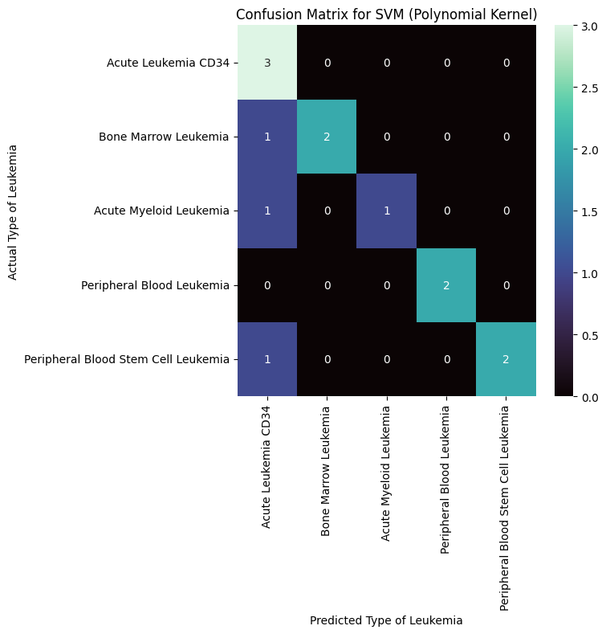

```python
#Calculate the confusion matrix for SVM (Polynomial Kernel)
cm = confusion_matrix(y_test, poly_pred)

#Visualizing the confusion matrix using seaborn
plt.figure(figsize=(6,6))
sns.heatmap(cm, annot=True, cmap='mako', xticklabels=df['actual_type'].unique(), yticklabels=df['actual_type'].unique())
plt.title("Confusion Matrix for SVM (Polynomial Kernel)")
plt.xlabel('Predicted Type of Leukemia')
plt.ylabel('Actual Type of Leukemia')
plt.show()
```

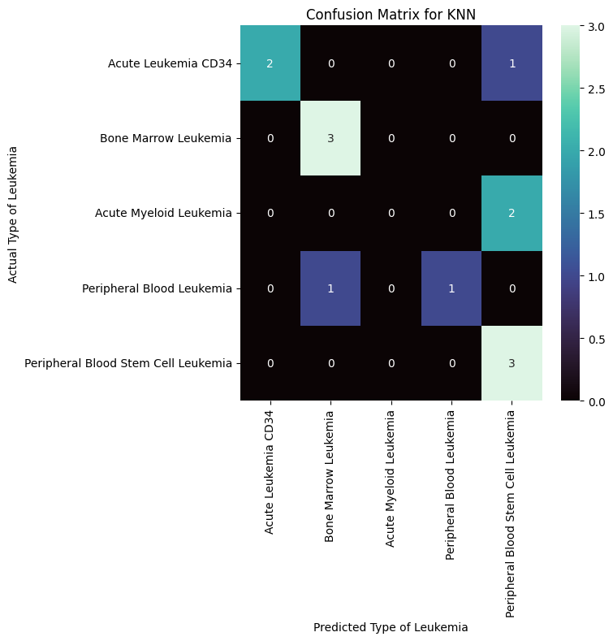

```python
#Calculate the confusion matrix for KNN
cm = confusion_matrix(y_test, knn_pred)

#Visualizing the confusion matrix using seaborn
plt.figure(figsize=(6,6))
sns.heatmap(cm, annot=True, cmap='mako', xticklabels=df['actual_type'].unique(), yticklabels=df['actual_type'].unique())
plt.title("Confusion Matrix for KNN")
plt.xlabel('Predicted Type of Leukemia')
plt.ylabel('Actual Type of Leukemia')
plt.show()
```

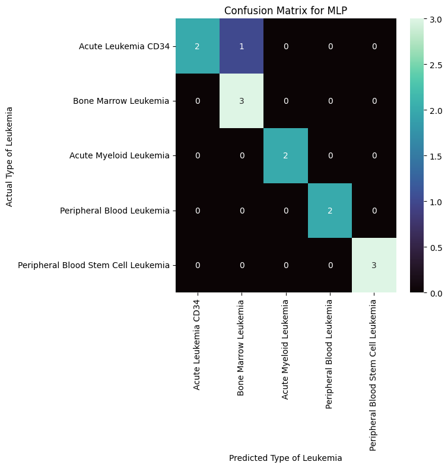

```python
#Calculate the confusion matrix for MLP
cm = confusion_matrix(y_test, mlp_pred)

#Visualizing the confusion matrix using seaborn
plt.figure(figsize=(6,6))
sns.heatmap(cm, annot=True, cmap='mako', xticklabels=df['actual_type'].unique(), yticklabels=df['actual_type'].unique())
plt.title("Confusion Matrix for MLP")
plt.xlabel('Predicted Type of Leukemia')
plt.ylabel('Actual Type of Leukemia')
plt.show()
```

## **Insights and Conclusions**

In our primary analysis, we trained several different types of multi-class classifiers to use the gene expression levels of a patient to predict the type of leukemia they have. We then evaluated the classifiers on a held-out testing dataset, determining the accuracy, F1-score, and R^2 score for all the models. Using these metrics, we can determine which type of classifier had the strongest performance, which was the Multilayer Perceptron classifier. This model achieved the highest accuracy of 0.92, the highest F1-score of 0.92, and the highest coefficient of determination of 0.96. A R^2 score of 0.96 means that approximately 96% of the variation in the dependent variable (type of leukemia) was predicted by the machine-learning model. The second-best model is the Random Forest classifier as it achieved the second highest values for accuracy, F1-score, and R^2 score at 0.85, 0.84, and 0.65 respectively. The K-Nearest Neighbor, SVM, and Decision Tree classifiers significantly underperformed when compared to the other classifiers. The K-Nearest Neighbor and Decision Tree classifiers achieved low accuracies and F1-scores around 0.6. With these metrics and the results from the confusion matrix visualization, it is evident that from our primary analysis, the best classification model for our dataset is the Multilayer Perceptron classifier.

The Multilayer Perceptron classifier performed the best for our project because our dataset involved over 22000 features, which meant that the dataset was very high-dimensional. With high-dimensional datasets, there can be a phenomena named “curse of dimensionality”, which is when models underperform because the high-dimensional data is too sparse. The data sparsity negatively affects K-Nearest Neighbors because in high-dimensional spaces, the concept of “distances” between points becomes less meaningful. Decision Tree classifiers tend to overfit on high-dimensional data too as the tree becomes substantially large and tends to memorize the noise in the dataset rather than capture the underlying pattern. In our dataset, the relationships between gene expression levels and the type of leukemia might also be nonlinear as evidenced in our exploratory data analysis. This means that classifiers like Support Vector Machines would perform poorly on our dataset as they would need to use some kernel trick to model these nonlinear relationships. Multilayer Perceptron classifiers avoid all the other pitfalls that these other models fall into. This is because Multilayer Perceptrons are a neural network made up of several connected layers of neurons, which can handle the high-dimensional data from our dataset. Between each layer in the network, there is also an activation function which allows the network to model nonlinear relationships. Thus, since Multilayer Perceptron classifiers perform well on multi-class classification with high-dimensional data and nonlinear relationships, they are the best model we should use to predict the type of leukemia a patient has.

With our Multilayer Perceptron model, we can get a 92% accuracy on the testing portion of our dataset, which means that in most cases, our model can accurately predict the type of leukemia a patient has based on their gene expression levels. We can connect this back to our research question and now determine that there is a relationship between the gene expression levels of a human and different types of leukemia. Our machine-learning model is able to discern these patterns from our dataset and accurately predict the type of leukemia a patient has. This is highly important in the medical field because our machine-learning model can be used to do quick and early diagnosis for leukemia. As mentioned before, many traditional diagnostic tests for leukemia only work after certain symptoms appear, which can be significantly far into a patient’s treatment. Our machine-learning model just needs gene expression levels which can be measured for a human at any time, allowing us to use our machine-learning model to screen for leukemia well ahead of other diagnostic tests. Moreover, our machine-learning model is also much faster than other leukemia diagnostic tests which can take anywhere from a week to a month on average to receive results from. On the other hand, our model just needs the gene expression levels, and then, the actual testing part of the levels can happen with the model in a few seconds. Finally, an idea to improve our project is to see whether we can achieve a similar level of accuracy by using fewer features as this would make it much easier to train and use our models. We can also try adapting our approach to other cancer datasets and see if we are able to discern similar relationships in the data. In the end, we were able to train a classifier model on our dataset that achieved a 92% accuracy in predicting the type of leukemia from the gene expression levels of a patient.

## **References**

1. Brownlee, J. (2022, August 2). Crash course on multi-layer perceptron neural networks. Machine Learning Mastery. https://machinelearningmastery.com/neural-networks-crash-course/
2. Feltes, B.C.; Chandelier, E.B.; Grisci, B.I.; Dorn, M. CuMiDa: An Extensively Curate Microarray Database for Benchmarking and Testing of Machine Learning Approaches in Cancer Research. Journal of Computational Biology, 2019.
3. IBM. (2024, March 26). What is a decision tree?. IBM. https://www.ibm.com/topics/decision-trees#:~:text=A%20decision%20tree%20is%20a,internal%20nodes%20and%20leaf%20nodes.
4. Jiang, Z., Wu, D., Lin, S., & Li, P. (2016, December 16). CD34 and CD38 are prognostic biomarkers for acute B lymphoblastic leukemia. Nation Library of Medicine. https://www.ncbi.nlm.nih.gov/pmc/articles/PMC5159997/
5. National Cancer Institute. (n.d.). Leukemia-Patient Version. National Cancer Institute. https://www.cancer.gov/types/leukemia#:~:text=Leukemia%20is%20a%20broad%20term,in%20children%20younger%20than%2015
6. Pruthi, S. (2022, September 21). Leukemia. Mayo Clinic. https://www.mayoclinic.org/diseases-conditions/leukemia/diagnosis-treatment/drc-20374378
7. Shetty, B. (n.d.). What is the curse of dimensionality?. Builtin. https://builtin.com/data-science/curse-dimensionality
8. University of Rochester Medical Center. (n.d.). Leukemia: Risk factors. University of Rochester Medical Center. https://www.urmc.rochester.edu/encyclopedia/content.aspx?contenttypeid=34&contentid=17601-1